# Lab 3: Binary Logistic Regression

Sophia Leiker

1/28/2022

```r
knitr::opts_chunk$set(echo = TRUE, warning = FALSE, message = FALSE)

library(tidyverse)
library(palmerpenguins)
library(GGally)
library(broom)
library(jtools)
library(caret)
library(AICcmodavg)
```

### Intro

In lectures this week, we are learning about logistic regression - where based on predictor variables, we can estimate the probability of different discrete outcomes for a categorical variable. If there are only two mutually exclusive outcomes, we might use *binary logistic regression*, and for > 2 mutually exclusive outcomes we might use *multinomial logistic regression.* If the dependent variable is *ordinal* (discrete levels with meaningful order), we might use *ordinal logistic regression*.

Here, we will use *binary logistic regression* to find probabilities that a penguin is species Chinstrap or Adelie, based on several variables. We’ll compare the performance of two competing models using AIC and cross validation, based on how accurately it classifies the penguin species.

### 1. Binary logistic regression

#### a. Exploration with `ggpairs`

First, let’s remind ourselves of the penguins data. We will only consider variables species, bill depth, bill length, body mass, flipper length and sex.

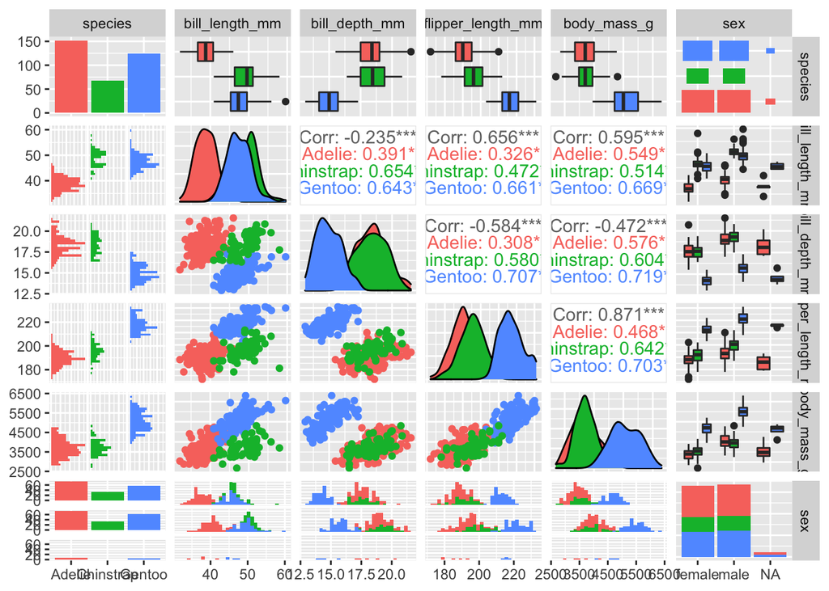

```r
penguins %>%
  select(species, bill_length_mm:sex) %>%
  ggpairs(aes(color=species))
```

We want to explore the relationship between bill length, depth, mass, flipper length, and sex (those will be our explanatory variables) and penguin species (that’s our dependent variable).

To start, we’ll just choose two species (those that are *most similar* across these variables to make it interesting), Adelie and Chinstrap penguins.

#### b. Make subset with Adelie and Chinstrap penguins

- This is because we can only look at two of them through binary logistic regression

```r
### note species is a factor
class(penguins$species)
```

```
## [1] "factor"
```

```r
levels(penguins$species)
```

```
## [1] "Adelie"    "Chinstrap" "Gentoo"
```

```r
adelie_chinstrap <- penguins %>%
  filter(species %in% c('Adelie', 'Chinstrap')) %>%
  mutate(species = fct_drop(species)) %>%
  select(-island, -year) %>%
  drop_na()

### This will drop a factor level that doesn't appear (otherwise Gentoo will still show up as a factor level, even though there are no remaining
### observations for Gentoo penguins...)

### Check the levels (note here Adelie is before Chinstrap, so Adelie
### will be 0, Chinstrap will be 1)
class(adelie_chinstrap$species)
```

```
## [1] "factor"
```

```r
levels(adelie_chinstrap$species)
```

```
## [1] "Adelie"    "Chinstrap"
```

#### c. Let’s just check out trends across variables for those two species

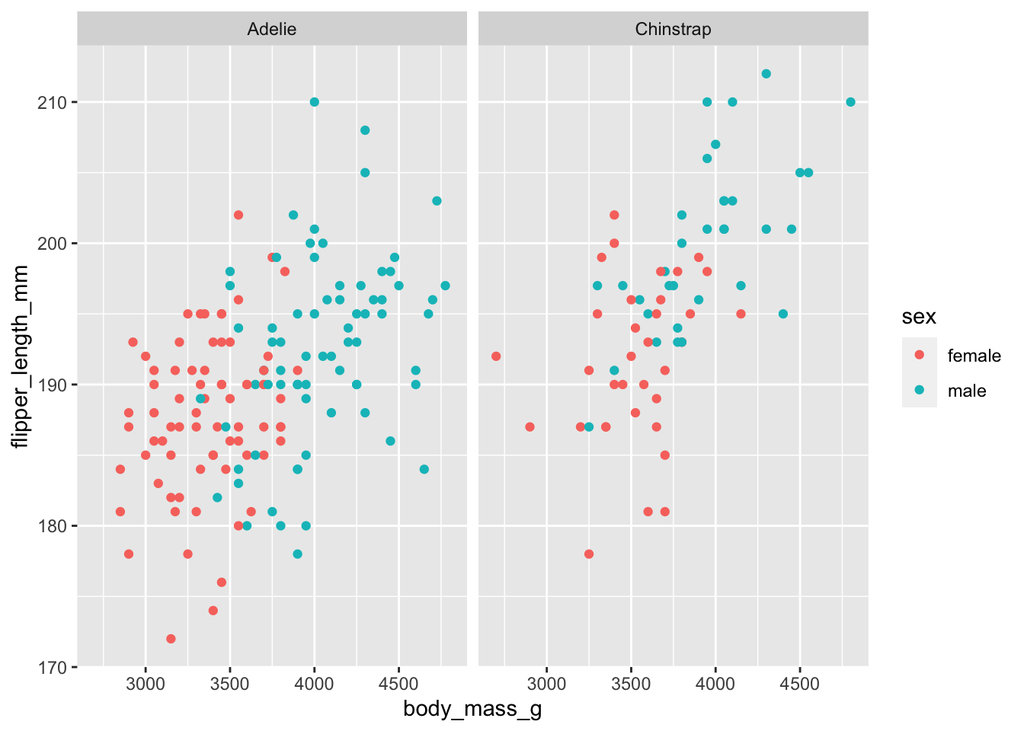

```r
ggplot(data = adelie_chinstrap, aes(x = body_mass_g, y = flipper_length_mm)) +
  geom_point(aes(color = sex)) +
  facet_wrap(~species)
```

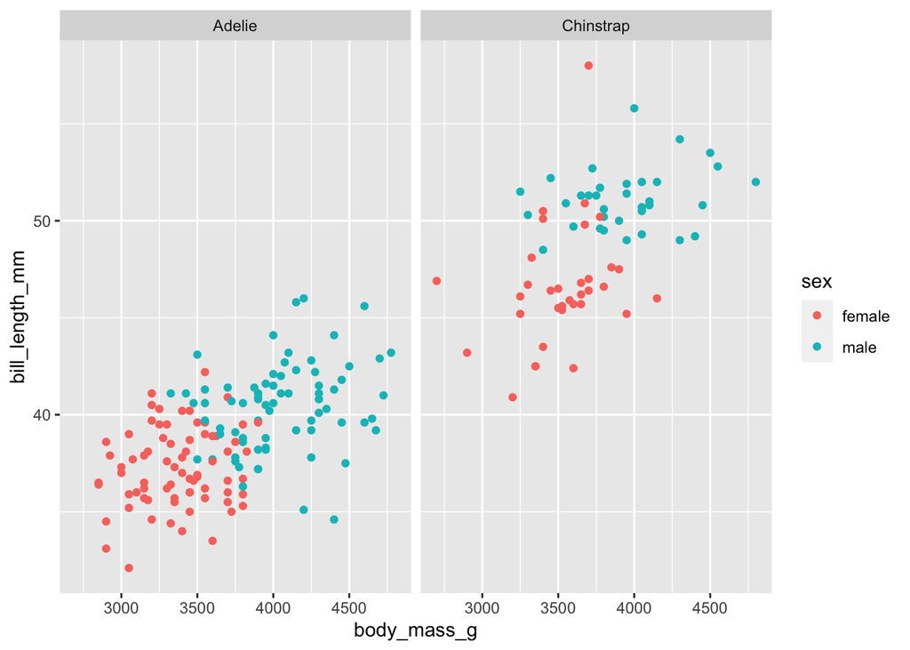

```r
ggplot(data = adelie_chinstrap, aes(x = body_mass_g, y = bill_length_mm)) +
  geom_point(aes(color = sex)) +
  facet_wrap(~species)
```

```r
#For both species males seem to be in upper right hand corner while females seem to be in lower left hand corner
```

#### Logistic Regression in R

- Let’s first try to predict penguin species as a function of body mass, flipper length, and sex

```r
f1 <- species ~ body_mass_g + flipper_length_mm + sex

#Gineralized Linear Model

ad_chin_blr1 <- glm(formula = f1,
                    data = adelie_chinstrap,
                    family = "binomial")
```

Look at the results:

```r
ad_chin_blr1
```

```
##
## Call:  glm(formula = f1, family = "binomial", data = adelie_chinstrap)
##
## Coefficients:
##       (Intercept)        body_mass_g  flipper_length_mm            sexmale
##        -3.161e+01         -8.576e-04          1.778e-01         -5.716e-01
##
## Degrees of Freedom: 213 Total (i.e. Null);  210 Residual
## Null Deviance:       267.6
## Residual Deviance: 226.4     AIC: 234.4
```

```r
summary(ad_chin_blr1)
```

```
##
## Call:
## glm(formula = f1, family = "binomial", data = adelie_chinstrap)
##
## Deviance Residuals:
##     Min       1Q   Median       3Q      Max
## -1.9456  -0.8195  -0.5581   1.0065   2.3698
##
## Coefficients:
##                     Estimate Std. Error z value Pr(>|z|)
## (Intercept)       -3.161e+01  5.784e+00  -5.465 4.63e-08 ***
## body_mass_g       -8.576e-04  5.428e-04  -1.580    0.114
## flipper_length_mm  1.778e-01  3.236e-02   5.495 3.91e-08 ***
## sexmale           -5.716e-01  4.499e-01  -1.270    0.204
## ---
## Signif. codes:  0 '***' 0.001 '**' 0.01 '*' 0.05 '.' 0.1 ' ' 1
##
## (Dispersion parameter for binomial family taken to be 1)
##
##     Null deviance: 267.57  on 213  degrees of freedom
## Residual deviance: 226.45  on 210  degrees of freedom
## AIC: 234.45
##
## Number of Fisher Scoring iterations: 4
```

```r
#Intercept and flipper length both have low p value meaning they must be significant
#use levels(adelie_chinstrap$species) to get our levels if we were to increase by body madd by one gram, for every gram of additional body mass -> it makes it a little less likely it is a chinstrap penguin.
#For flipper length it is positive, for every additionally mm of flipper length, more liklely it is a chinstrap

blr1_tidy <- broom::tidy(ad_chin_blr1)
```

How can we start thinking about this?

- These are coefficients for the log-linear model (e.g. these are coefficients for the predictor variables that relate to the *log odds* of the “Chinstrap” outcome).
- The null hypothesis for coefficients is that they = 0
- The coefficient for body mass, -8.6^{-4}, indicates that on average we expect the log odds of a penguin being a Chinstrap (remember, that’s the ‘1’ outcome) decreases by -8.6^{-4} for each 1 g increase in penguin body mass (see `blr1_tidy` - this coefficient is not significant).

Does this align with the mass comparisons for Chinstraps & Adelies we see?

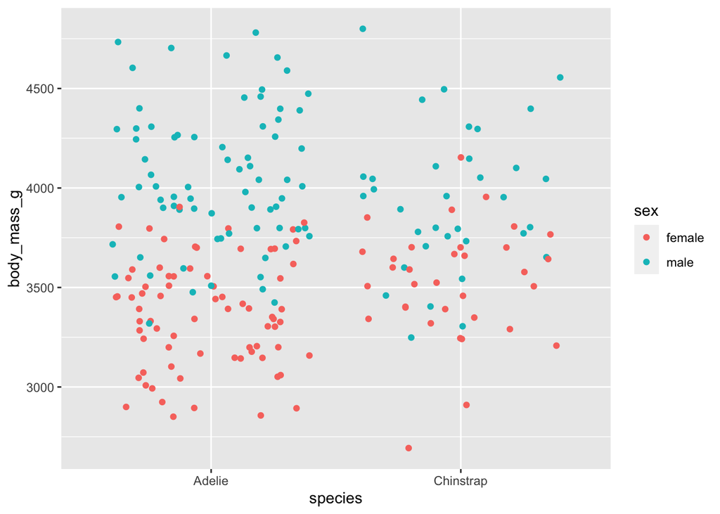

```r
ggplot(data = adelie_chinstrap, aes(x = species, y = body_mass_g)) +
  geom_jitter(aes(color = sex))
```

- The coefficient for flipper length, 0.18, indicates that on average we expect the log odds of a penguin being a Chinstrap (remember, that’s the ‘1’ outcome) increases by 0.18 for each 1 mm increase in penguin flipper length (see `blr1_tidy` - this coefficient is significant).

Does this align with the flipper comparisons for Chinstraps & Adelies we see?

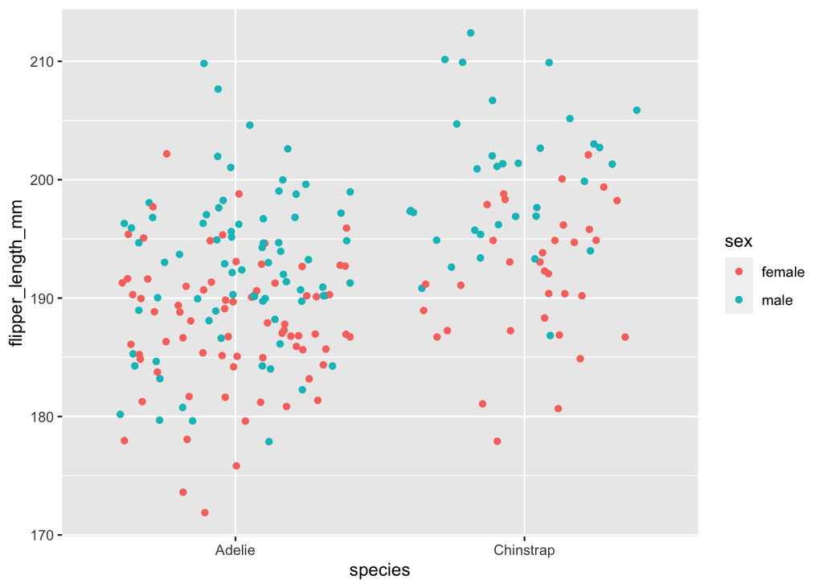

```r
ggplot(data = adelie_chinstrap, aes(x = species, y = flipper_length_mm)) +
  geom_jitter(aes(color = sex))
```

- The coefficient for sex, -0.57, indicates that on average we expect the log odds of a penguin being a Chinstrap (remember, that’s the ‘1’ outcome) decreases by -0.57 if the penguin is Male, compared to Female (this is a weird example – but you can imagine relevant interpretations for other scenarios e.g. “The odds of supporting a bill for conservation (Y/N) increases if the individual identifies as an Environmentalist, compared to those who identify as Not an Environmentalist).”

But log odds are challenging to interpret. Let’s find actual *probabilities* associated with a penguin being Adelie or Chinstrap, based on the selected variables and the model outcome.

Adding `type.predict = "response"` here converts the log odds (link), the default reported, to the probability of being Chinstrap for each observation.

```r
blr1_fitted <- ad_chin_blr1 %>%
  broom::augment(type.predict = "response")
```

Look at the outcome data frame.

A number of the actual Chinstraps (if we weren’t looking at the actual observation) have, based on the model, a higher probability of being an Adelie by classification. This demonstrates why, in Machine Learning, we need a training dataset (which we’d use to create the model), then a totally separate test dataset to see how successfully it classifies the outcome (e.g. penguin species here).

Let’s do a couple of quick visualizations, with flipper length (the only significant coefficient) on the x-axis and probability of being a Chinstrap on the y-axis:

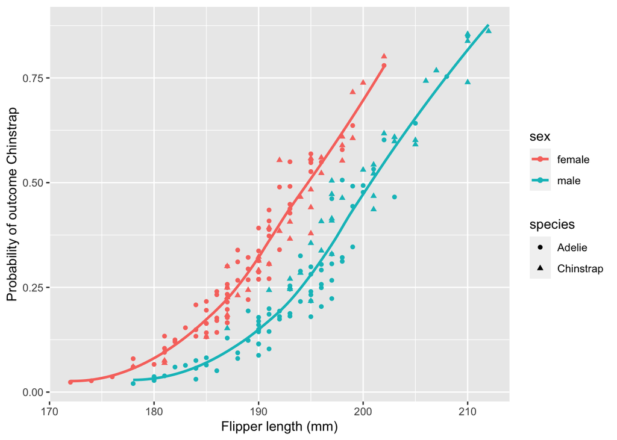

```r
ggplot(data = blr1_fitted, aes(x = flipper_length_mm, y = .fitted)) +
  ### add aes(shape = species) to compare probability with actual
  geom_point(aes(color = sex, shape = species)) +
  ### add geom_smooth to show general fit
  geom_smooth(aes(color = sex), se = FALSE) +
  labs(x = "Flipper length (mm)",
       y = "Probability of outcome Chinstrap")
```

#### Visualization of p(Chinstrap) by variable

The `jtools::effect_plot()` function provides some quick model plotting. Note: for more customized visualization of model predictions, you may want to create a new “test” data frame of theoretical values, then use the `predict()` function to append predicted probabilities before plotting in `ggplot()`.

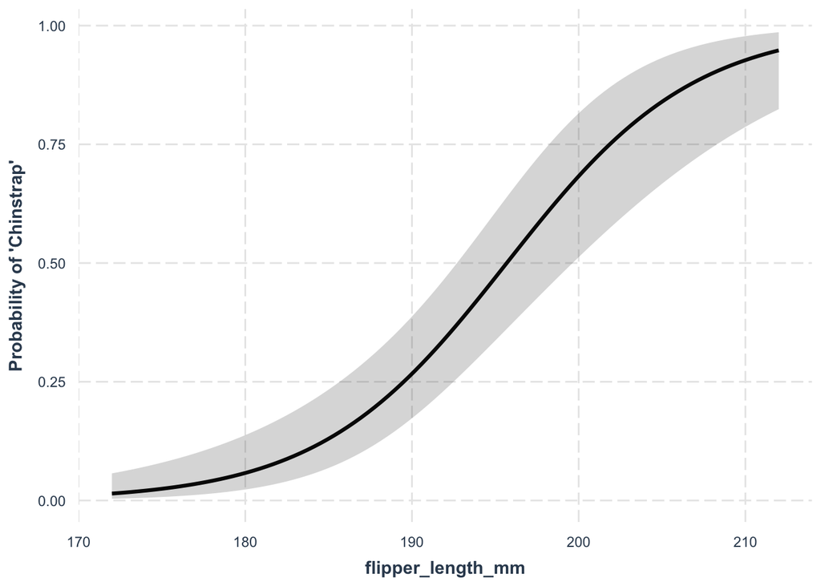

```r
# For flipper length:
effect_plot(ad_chin_blr1,
            pred = flipper_length_mm,
            interval = TRUE,
            y.label = "Probability of 'Chinstrap'")
```

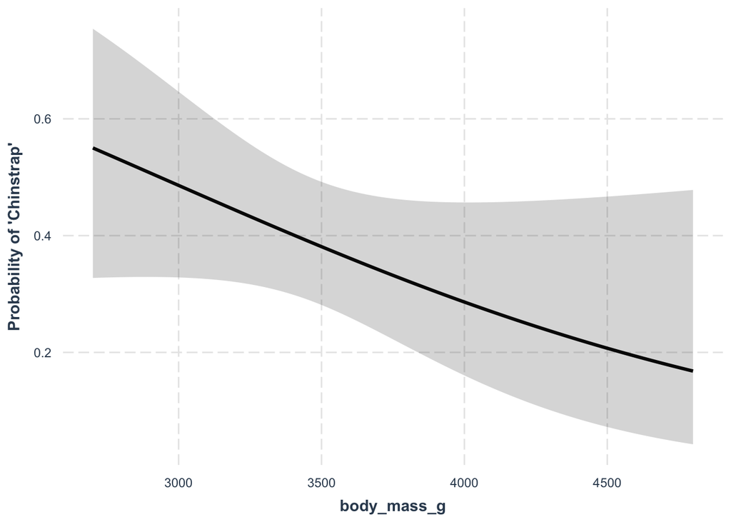

```r
#lower values of flipper length generally lead to predictions of adelies, higher values will lead to predictions of chinstrap

# For body mass:
effect_plot(ad_chin_blr1,
            pred = body_mass_g,
            interval = TRUE,
            y.label = "Probability of 'Chinstrap'")
```

#### Predictions for new values with `predict()`

- Use the predict function

What is the probability that a female penguin weight 3410 g with a flipper length of 192 mm will be Chinstrap?

```r
#this is creating a dataframe with a single row to predict on one
ex_1 <- predict(ad_chin_blr1,
                data.frame(sex = "female",
                  body_mass_g = 3410,
                  flipper_length_mm = 192),
                ### tell it type = 'response' to get prob, not log odds
                type = "response")

# Based on the model, the probability that this penguin is a Chinstrap is 0.4.
```

You can also feed in a new data frame, with multiple penguin observations, to get model probability estimates for more than one penguin:

```r
new_df <- data.frame(
  sex = c("male", "male", "female"),
  body_mass_g = c(3298, 4100, 3600),
  flipper_length_mm = c(212, 175, 180)
)

ex_2 <- predict(ad_chin_blr1,
                    new_df,
                    type = "response")

#0.93625508 (high probability chinstrap) 0.01015363(low probability chinstrap) 0.06354910
```

#### e. Binary logistic regression - new model: Bill length

```r
f2 <- species ~ bill_length_mm + body_mass_g

ad_chin_blr2 <- glm(formula = f2,
                    data = adelie_chinstrap,
                    family = "binomial")
```

Look at the model

```r
ad_chin_blr2
```

```
##
## Call:  glm(formula = f2, family = "binomial", data = adelie_chinstrap)
##
## Coefficients:
##    (Intercept)  bill_length_mm     body_mass_g
##      -68.15326         2.72188        -0.01371
##
## Degrees of Freedom: 213 Total (i.e. Null);  211 Residual
## Null Deviance:       267.6
## Residual Deviance: 17    AIC: 23
```

```r
summary(ad_chin_blr2)
```

```
##
## Call:
## glm(formula = f2, family = "binomial", data = adelie_chinstrap)
##
## Deviance Residuals:
##      Min        1Q    Median        3Q       Max
## -1.70697  -0.00556  -0.00023   0.00006   2.09831
##
## Coefficients:
##                  Estimate Std. Error z value Pr(>|z|)
## (Intercept)    -68.153259  25.041441  -2.722  0.00650 **
## bill_length_mm   2.721885   1.024164   2.658  0.00787 **
## body_mass_g     -0.013705   0.005647  -2.427  0.01523 *
## ---
## Signif. codes:  0 '***' 0.001 '**' 0.01 '*' 0.05 '.' 0.1 ' ' 1
##
## (Dispersion parameter for binomial family taken to be 1)
##
##     Null deviance: 267.572  on 213  degrees of freedom
## Residual deviance:  17.003  on 211  degrees of freedom
## AIC: 23.003
##
## Number of Fisher Scoring iterations: 11
```

```r
# Bill length --> positive big number (mean for additional mm of bill length, change in log odds is +2.7 --> more lickely to have chinstrap than adelie penguin)
#for every additional g of body mass , a little lower odds it is a chinstrap

### Get a tidy version w/ broom:
blr2_tidy <- broom::tidy(ad_chin_blr2)
```

Let’s see if this makes sense based on a visual comparison:

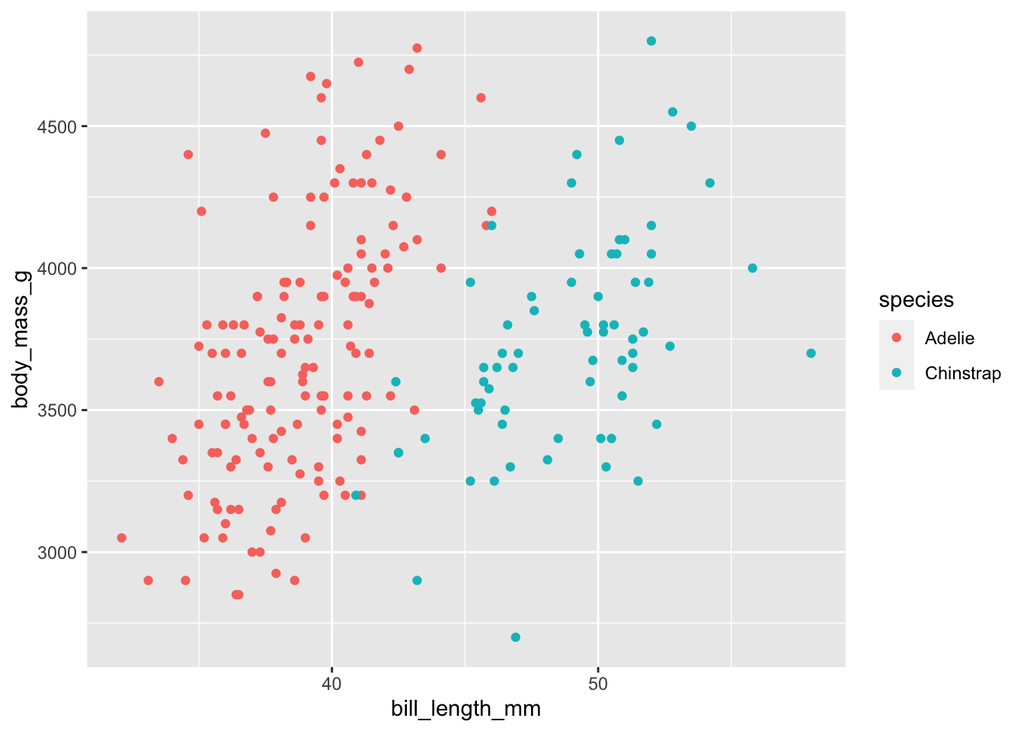

```r
ggplot(adelie_chinstrap, aes(x = bill_length_mm, y = body_mass_g)) +
  geom_point(aes(color = species))
```

```r
#differentiating with bill length and body mass they are more easily differentiated, can divide these with a line
```

Let’s visualize the results for this model like we did before:

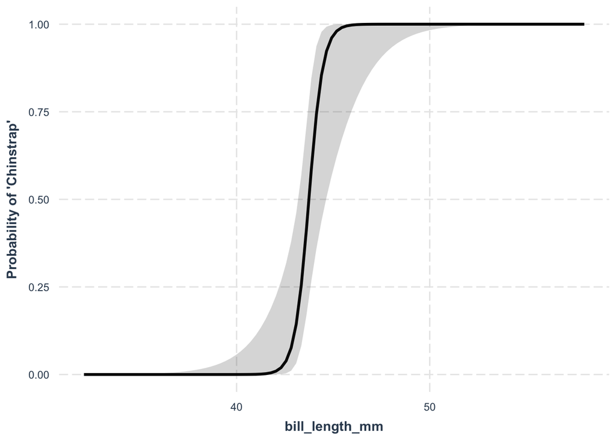

```r
effect_plot(ad_chin_blr2,
            pred = bill_length_mm,
            interval = TRUE,
            y.label = "Probability of 'Chinstrap'")
```

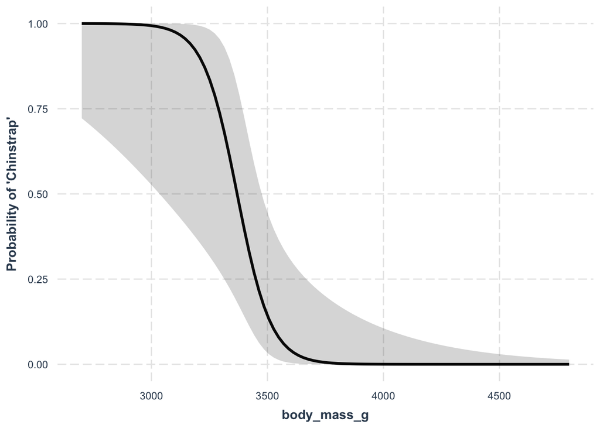

```r
#Sharp divide, once you get to bottom, pretty clearly likly not chinstrap, at the top, highly likly it is a chinstrap

effect_plot(ad_chin_blr2,
            pred = body_mass_g,
            interval = TRUE,
            y.label = "Probability of 'Chinstrap'")
```

```r
#if above around 3700 pretty sure you are going to have an adelie
```

#### Model selection

Let’s compare the models using AICc (AIC corrected for sample sizes), AIC tab compares for a bunch

```r
AICcmodavg::aictab(list(ad_chin_blr1, ad_chin_blr2))
```

```
##
## Model selection based on AICc:
##
##      K   AICc Delta_AICc AICcWt Cum.Wt      LL
## Mod2 3  23.12       0.00      1      1   -8.50
## Mod1 4 234.64     211.52      0      1 -113.22
```

Model 2 is better of the 2, model 1 is much worse. We want delta AIC of 2, and in this case we have a delta AIC of 200, so there is clearly a better model.

And let’s compare with a 10-fold cross-validation, using prediction accuracy as our metric.

- We are doing this manually this time, but there is a package to use moving forward

```r
set.seed(123)

n_folds <- 10
folds <- rep(1:n_folds, length.out = nrow(adelie_chinstrap))
ad_chin_kfold <- adelie_chinstrap %>%
  mutate(fold = sample(folds, size = n(), replace = FALSE))

#creating out function
pred_acc <- function(x, y) {
  accurate <- ifelse(x == y, 1, 0)
  return(mean(accurate, na.rm = TRUE))
}

#Creating empty data frame and running a loop on it which will populate it
results_df <- data.frame()
for(i in 1:n_folds) {
   kfold_test <- ad_chin_kfold %>%
    filter(fold == i)
  kfold_train <- ad_chin_kfold %>%
    filter(fold != i)

  kfold_blr1 <- glm(f1, data = kfold_train, family = 'binomial')
  kfold_blr2 <- glm(f2, data = kfold_train, family = 'binomial')
  kfold_pred <- kfold_test %>%
    mutate(blr1 = predict(kfold_blr1, kfold_test, type = 'response'),
           blr2 = predict(kfold_blr2, ., type = 'response')) %>%
    mutate(pred1 = ifelse(blr1 > 0.50, 'Chinstrap', 'Adelie'),
           pred2 = ifelse(blr2 > 0.50, 'Chinstrap', 'Adelie'))
  kfold_accuracy <- kfold_pred %>%
    summarize(blr1_acc = pred_acc(species, pred1),
              blr2_acc = pred_acc(species, pred2))

  results_df <- bind_rows(results_df, kfold_accuracy)
}

results_df %>%
  summarize(blr1_acc = mean(blr1_acc),
            blr2_acc = mean(blr2_acc))
```

```
##    blr1_acc  blr2_acc
## 1 0.7145022 0.9720779
```

#### using `caret` (“**C**lassification **A**nd **RE**gression **T**raining”):

- This is automating the k-fold cross validation

```r
set.seed(123)
#tr_ctrl <- trainControl(method = "cv", number = 10)
tr_ctrl <- trainControl(method = "repeatedcv", number = 10, repeats = 10)

# Train the model
#Formula f1, data frame, method is the generalized linear model
model1 <- train(f1, data = adelie_chinstrap,
               method = "glm", family = 'binomial',
               trControl = tr_ctrl)
model1
```

```
## Generalized Linear Model
##
## 214 samples
##   3 predictor
##   2 classes: 'Adelie', 'Chinstrap'
##
## No pre-processing
## Resampling: Cross-Validated (10 fold, repeated 10 times)
## Summary of sample sizes: 192, 193, 193, 193, 192, 193, ...
## Resampling results:
##
##   Accuracy   Kappa
##   0.7197879  0.2904873
```

```r
#Accuracy   Kappa
#0.7197879  0.2904873

model2 <- train(f2, data = adelie_chinstrap,
               method = "glm", family = 'binomial',
               trControl = tr_ctrl)
model2
```

```
## Generalized Linear Model
##
## 214 samples
##   2 predictor
##   2 classes: 'Adelie', 'Chinstrap'
##
## No pre-processing
## Resampling: Cross-Validated (10 fold, repeated 10 times)
## Summary of sample sizes: 192, 193, 192, 194, 192, 192, ...
## Resampling results:
##
##   Accuracy   Kappa
##   0.9709221  0.9334481
```

```r
#Accuracy   Kappa
#0.9709221  0.9334481

#since the accuracy for model 2 is much higher, it is clear that the chosen model should be model 2
```

[output not shown]